# Data Scientist Nanodegree

## Project: Finding Donors for *CharityML*

### Sarah Brown - 07/04/2023

#### Python 3

## Introduction

In this project, I will employ several supervised algorithms to accurately model individuals' income using data collected from the 1994 U.S. Census. I will then choose the best candidate algorithm from preliminary results and further optimise this algorithm to best model the data.

My goal with this implementation is to construct a model that accurately predicts whether an individual makes more than $50,000. This sort of task can arise in a non-profit setting, where organizations survive on donations. Understanding an individual's income can help a non-profit better understand how large of a donation to request, or whether or not they should reach out to begin with. While it can be difficult to determine an individual's general income bracket directly from public sources, we can infer this value from other publically available features.

The dataset for this project originates from the [UCI Machine Learning Repository](https://archive.ics.uci.edu/ml/datasets/Census+Income). The datset was donated by Ron Kohavi and Barry Becker, after being published in the article *"Scaling Up the Accuracy of Naive-Bayes Classifiers: A Decision-Tree Hybrid"*. The article by Ron Kohavi can be found here [online](https://www.aaai.org/Papers/KDD/1996/KDD96-033.pdf). The data I investigate here consists of small changes to the original dataset, such as removing the `'fnlwgt'` feature and records with missing or ill-formatted entries.

## Exploring the Data

The code in the cell below loads the necessary Python libraries and the census data. Note that the last column from this dataset, `'income'`, is the target label (whether an individual makes more than, or at most, $50,000 annually). All other columns are features about each individual in the census database.

```python
# Import libraries necessary for this project
import numpy as np
import pandas as pd
from time import time
from IPython.display import display # Allows the use of display() for DataFrames

# Import supplementary visualization code visuals.py
import visuals as vs

# Pretty display for notebooks
%matplotlib inline

# Load the Census dataset
data = pd.read_csv("census.csv")

# Success - Display the first record
display(data.head(n=1))
```

|  | age | workclass | education_level | education-num | marital-status | occupation | relationship | race | sex | capital-gain | capital-loss | hours-per-week | native-country | income |
| --- | --- | --- | --- | --- | --- | --- | --- | --- | --- | --- | --- | --- | --- | --- |
| 0 | 39 | State-gov | Bachelors | 13.0 | Never-married | Adm-clerical | Not-in-family | White | Male | 2174.0 | 0.0 | 40.0 | United-States | <=50K |

### Implementation: Data Exploration

A cursory investigation of the dataset will determine how many individuals fit into either group, and will tell us about the percentage of these individuals making more than \$50,000. In the code cell below, I compute the following:

- The total number of records, `'n_records'`
- The number of individuals making more than \$50,000 annually, `'n_greater_50k'`.
- The number of individuals making at most \$50,000 annually, `'n_at_most_50k'`.
- The percentage of individuals making more than \$50,000 annually, `'greater_percent'`.

```python
data.shape
```

```
(45222, 14)
```

```python
data.info()
```

```
<class 'pandas.core.frame.DataFrame'>
RangeIndex: 45222 entries, 0 to 45221
Data columns (total 14 columns):
age                45222 non-null int64
workclass          45222 non-null object
education_level    45222 non-null object
education-num      45222 non-null float64
marital-status     45222 non-null object
occupation         45222 non-null object
relationship       45222 non-null object
race               45222 non-null object
sex                45222 non-null object
capital-gain       45222 non-null float64
capital-loss       45222 non-null float64
hours-per-week     45222 non-null float64
native-country     45222 non-null object
income             45222 non-null object
dtypes: float64(4), int64(1), object(9)
memory usage: 4.8+ MB
```

```python
data.nunique()
```

```
age                 74
workclass            7
education_level     16
education-num       16
marital-status       7
occupation          14
relationship         6
race                 5
sex                  2
capital-gain       121
capital-loss        97
hours-per-week      96
native-country      41
income               2
dtype: int64
```

```python
data.income.value_counts()
```

```
<=50K    34014
>50K     11208
Name: income, dtype: int64
```

```python
# Total number of records
n_records = 45222

# Number of records where individual's income is more than $50,000
n_greater_50k = 11208

# Number of records where individual's income is at most $50,000
n_at_most_50k = 34014

# Percentage of individuals whose income is more than $50,000
greater_percent = n_greater_50k / n_records

# Print the results
print("Total number of records: {}".format(n_records))
print("Individuals making more than $50,000: {}".format(n_greater_50k))
print("Individuals making at most $50,000: {}".format(n_at_most_50k))
print("Percentage of individuals making more than $50,000: {}%".format(greater_percent))
```

[output not shown]

### Featureset Exploration

Which possible data entries can be found in each column?

- **age**: continuous.
- **workclass**: Private, Self-emp-not-inc, Self-emp-inc, Federal-gov, Local-gov, State-gov, Without-pay, Never-worked.
- **education**: Bachelors, Some-college, 11th, HS-grad, Prof-school, Assoc-acdm, Assoc-voc, 9th, 7th-8th, 12th, Masters, 1st-4th, 10th, Doctorate, 5th-6th, Preschool.
- **education-num**: continuous.
- **marital-status**: Married-civ-spouse, Divorced, Never-married, Separated, Widowed, Married-spouse-absent, Married-AF-spouse.
- **occupation**: Tech-support, Craft-repair, Other-service, Sales, Exec-managerial, Prof-specialty, Handlers-cleaners, Machine-op-inspct, Adm-clerical, Farming-fishing, Transport-moving, Priv-house-serv, Protective-serv, Armed-Forces.
- **relationship**: Wife, Own-child, Husband, Not-in-family, Other-relative, Unmarried.
- **race**: Black, White, Asian-Pac-Islander, Amer-Indian-Eskimo, Other.
- **sex**: Female, Male.
- **capital-gain**: continuous.
- **capital-loss**: continuous.
- **hours-per-week**: continuous.
- **native-country**: United-States, Cambodia, England, Puerto-Rico, Canada, Germany, Outlying-US(Guam-USVI-etc), India, Japan, Greece, South, China, Cuba, Iran, Honduras, Philippines, Italy, Poland, Jamaica, Vietnam, Mexico, Portugal, Ireland, France, Dominican-Republic, Laos, Ecuador, Taiwan, Haiti, Columbia, Hungary, Guatemala, Nicaragua, Scotland, Thailand, Yugoslavia, El-Salvador, Trinadad&Tobago, Peru, Hong, Holand-Netherlands.

## Preparing the Data

Before data can be used as input for machine learning algorithms, it often must be cleaned, formatted, and restructured — this is typically known as **preprocessing**. Fortunately, for this dataset, there were no invalid or missing entries to deal with, however, there are some qualities about certain features that must be adjusted. This preprocessing helps with the outcome and predictive power of nearly all learning algorithms.

### Transforming Skewed Continuous Features

A dataset may sometimes contain at least one feature whose values tend to lie near a single number, but will also have a non-trivial number of vastly larger or smaller values than that single number. Algorithms can be sensitive to such distributions of values and can underperform if the range is not properly normalised. With the census dataset two features fit this description: '`capital-gain'` and `'capital-loss'`.

The code in the cell below splits the data into two parts: the income column and the features. Within the features set, I visualise the continuous features (capital-gain and capital-loss) using histograms. Note the large range of the values present and how they are distributed: many entries at 0 with a range of up to 100,000 with some clear anomalies.

[output not shown]

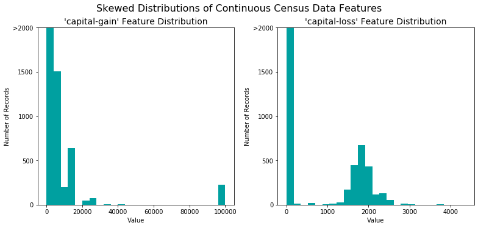

```python
# Split the data into features and target label
income_raw = data['income']
features_raw = data.drop('income', axis = 1)

# Visualize skewed continuous features of original data
vs.distribution(data)
```

For highly-skewed feature distributions such as `'capital-gain'` and `'capital-loss'`, it is common practice to apply a logarithmic transformation on the data so that the very large and very small values do not negatively affect the performance of a learning algorithm. Using a logarithmic transformation significantly reduces the range of values caused by outliers. Care must be taken when applying this transformation however: The logarithm of `0` is undefined, so the values must be translated by a small amount above `0` to apply the the logarithm successfully.

The code in the cell below performs a transformation on the data and visualises the results with histograms. The data are now better distributed over a smaller range, in clusters (apart from 0).

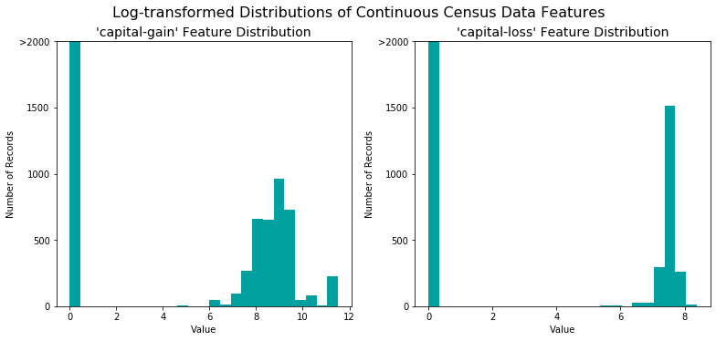

```python
# Log-transform the skewed features
skewed = ['capital-gain', 'capital-loss']
features_log_transformed = pd.DataFrame(data = features_raw)
features_log_transformed[skewed] = features_raw[skewed].apply(lambda x: np.log(x + 1))

# Visualise the new log distributions
vs.distribution(features_log_transformed, transformed = True)

# https://medium.com/@kyawsawhtoon/log-transformation-purpose-and-interpretation-9444b4b049c9
```

### Normalising Numerical Features

In addition to performing transformations on features that are highly skewed, it is often good practice to perform some type of scaling on numerical features. Applying a scaling to the data does not change the shape of each feature's distribution (such as `'capital-gain'` or `'capital-loss'` above); however, normalisation ensures that each feature is treated equally when applying supervised learners. Once scaling is applied, observing the data in its raw form will no longer have the same original meaning, as exampled below.

The code in the cell below is to normalise each numerical feature, using [`sklearn.preprocessing.MinMaxScaler`](http://scikit-learn.org/stable/modules/generated/sklearn.preprocessing.MinMaxScaler.html)

```python
# Import sklearn.preprocessing.StandardScaler
from sklearn.preprocessing import MinMaxScaler

# Initialise a scaler, then apply it to the features
scaler = MinMaxScaler() # default=(0, 1)
numerical = ['age', 'education-num', 'capital-gain', 'capital-loss', 'hours-per-week']

features_log_minmax_transform = pd.DataFrame(data = features_log_transformed)
features_log_minmax_transform[numerical] = scaler.fit_transform(features_log_transformed[numerical])

# Show an example of a record with scaling applied
display(features_log_minmax_transform.head(n = 5))
```

|  | age | workclass | education_level | education-num | marital-status | occupation | relationship | race | sex | capital-gain | capital-loss | hours-per-week | native-country |
| --- | --- | --- | --- | --- | --- | --- | --- | --- | --- | --- | --- | --- | --- |
| 0 | 0.301370 | State-gov | Bachelors | 0.800000 | Never-married | Adm-clerical | Not-in-family | White | Male | 0.667492 | 0.0 | 0.397959 | United-States |
| 1 | 0.452055 | Self-emp-not-inc | Bachelors | 0.800000 | Married-civ-spouse | Exec-managerial | Husband | White | Male | 0.000000 | 0.0 | 0.122449 | United-States |
| 2 | 0.287671 | Private | HS-grad | 0.533333 | Divorced | Handlers-cleaners | Not-in-family | White | Male | 0.000000 | 0.0 | 0.397959 | United-States |
| 3 | 0.493151 | Private | 11th | 0.400000 | Married-civ-spouse | Handlers-cleaners | Husband | Black | Male | 0.000000 | 0.0 | 0.397959 | United-States |
| 4 | 0.150685 | Private | Bachelors | 0.800000 | Married-civ-spouse | Prof-specialty | Wife | Black | Female | 0.000000 | 0.0 | 0.397959 | Cuba |

### Implementation: Data Preprocessing

From the table in **Exploring the Data** above, several features can be observed for each record that are non-numeric. Typically, learning algorithms expect input to be numeric, which requires that non-numeric features (called *categorical variables*) be converted. One popular way to convert categorical variables is by using the **one-hot encoding** scheme. One-hot encoding creates a *"dummy"* variable for each possible category of each non-numeric feature. For example, assume `someFeature` has three possible entries: `A`, `B`, or `C`, then encode this feature into `someFeature_A`, `someFeature_B` and `someFeature_C`.

|  | someFeature |  | someFeature_A | someFeature_B | someFeature_C |
| --- | --- | --- | --- | --- | --- |
| 0 | B |  | 0 | 1 | 0 |
| 1 | C | ----> one-hot encode ----> | 0 | 0 | 1 |
| 2 | A |  | 1 | 0 | 0 |

Additionally, as with the non-numeric features, the non-numeric target label needs to be converted: `'income'` to numerical values for the learning algorithm to work. Since there are only two possible categories for this label ("<=50K" and ">50K"), one-hot encoding can be avoided and simply encoding these two categories as `0` and `1` respectively will suffice. The code in the cells below does the following:

- Uses [`pandas.get_dummies()`](http://pandas.pydata.org/pandas-docs/stable/generated/pandas.get_dummies.html?highlight=get_dummies#pandas.get_dummies) to perform one-hot encoding on the `'features_log_minmax_transform'` data.
- Converts the target label `'income_raw'` to numerical entries.
  - Set records with "<=50K" to `0` and records with ">50K" to `1`.

```python
income_raw.value_counts()
```

```
<=50K    34014
>50K     11208
Name: income, dtype: int64
```

```python
features_log_minmax_transform.head()
```

|  | age | workclass | education_level | education-num | marital-status | occupation | relationship | race | sex | capital-gain | capital-loss | hours-per-week | native-country |
| --- | --- | --- | --- | --- | --- | --- | --- | --- | --- | --- | --- | --- | --- |
| 0 | 0.301370 | State-gov | Bachelors | 0.800000 | Never-married | Adm-clerical | Not-in-family | White | Male | 0.667492 | 0.0 | 0.397959 | United-States |
| 1 | 0.452055 | Self-emp-not-inc | Bachelors | 0.800000 | Married-civ-spouse | Exec-managerial | Husband | White | Male | 0.000000 | 0.0 | 0.122449 | United-States |
| 2 | 0.287671 | Private | HS-grad | 0.533333 | Divorced | Handlers-cleaners | Not-in-family | White | Male | 0.000000 | 0.0 | 0.397959 | United-States |
| 3 | 0.493151 | Private | 11th | 0.400000 | Married-civ-spouse | Handlers-cleaners | Husband | Black | Male | 0.000000 | 0.0 | 0.397959 | United-States |
| 4 | 0.150685 | Private | Bachelors | 0.800000 | Married-civ-spouse | Prof-specialty | Wife | Black | Female | 0.000000 | 0.0 | 0.397959 | Cuba |

```python
# One-hot encode the 'features_log_minmax_transform' data using pandas.get_dummies()
# https://www.sharpsightlabs.com/blog/pandas-get-dummies/

features_final = pd.get_dummies(features_log_minmax_transform, columns = (['workclass', 'education_level', 'marital-status', 'occupation', 'relationship', 'race', 'sex', 'native-country'])
                                   ,drop_first = True
                                   )

# Encode the 'income_raw' data to numerical values
income = income_raw.map({'>50K': 1, '<=50K': 0})

# Print the number of features after one-hot encoding
encoded = list(features_final.columns)
print("{} total features after one-hot encoding.".format(len(encoded)))

# Uncomment the following line to see the encoded feature names
print(encoded)
```

[output not shown]

### Shuffle and Split Data

Now that all *categorical variables* have been converted into numerical features, and all numerical features have been normalised, I can split the data (both features and their labels) into training and test sets. 80% of the data will be used for training and 20% for testing.

The code in the cell below performs this split.

```python
# Import train_test_split
from sklearn.model_selection import train_test_split

# Split the 'features' and 'income' data into training and testing sets
X_train, X_test, y_train, y_test = train_test_split(features_final,
                                                    income,
                                                    test_size = 0.2,
                                                    random_state = 0)

# Show the results of the split
print("Training set has {} samples.".format(X_train.shape[0]))
print("Testing set has {} samples.".format(X_test.shape[0]))
```

```
Training set has 36177 samples.
Testing set has 9045 samples.
```

## Evaluating Model Performance

In this section, I investigate four different algorithms, and determine which is best at modeling the data. The first algorithm will be the Naive Predictor. I will then select three supervised learners.

### Metrics and the Naive Predictor

*CharityML*, equipped with their research, knows individuals that make more than \$50,000 are most likely to donate to their charity. Because of this, *CharityML* is particularly interested in predicting who makes more than \$50,000 accurately. It would seem that using **accuracy** as a metric for evaluating a particular model's performace would be appropriate. Additionally, identifying someone that *does not* make more than \$50,000 as someone who does would be detrimental to *CharityML*, since they are looking to find individuals willing to donate. Therefore, a model's ability to precisely predict those that make more than \$50,000 is *more important* than the model's ability to **recall** those individuals. We can use **F-beta score** as a metric that considers both precision and recall:

$$ F_{\beta} = (1 + \beta^2) \cdot \frac{precision \cdot recall}{\left( \beta^2 \cdot precision \right) + recall} $$

In particular, when $\beta = 0.5$, more emphasis is placed on precision. This is called the **F$_{0.5}$ score** (or F-score for simplicity).

Looking at the distribution of classes (those who make at most 50,000 dollars and those who make more), it is clear that most people earn less than 50,000.

This can greatly affect **accuracy**, since one could simply say *"this person does not make more than \$50,000"* and generally be right, without ever looking at the data. Making such a statement would be called **naive**, since not enough information has been considered to substantiate the claim. I consider the *naive prediction* for the data, to help establish a benchmark for whether a model is performing well. That being said, using the naive prediction would be pointless: If it predicted all people made less than \$50,000, *CharityML* would identify no one as donors.

#### Recap of accuracy, precision, recall

**Accuracy** measures how often the classifier makes the correct prediction. It’s the ratio of the number of correct predictions to the total number of predictions (the number of test data points).

**Precision** tells what proportion of messages we classified as spam, actually were spam. It is a ratio of true positives(words classified as spam, and which are actually spam) to all positives(all words classified as spam, irrespective of whether that was the correct classificatio), in other words it is the ratio of

`[True Positives/(True Positives + False Positives)]`

**Recall(sensitivity)** tells what proportion of messages that actually were spam were classified as spam. It is a ratio of true positives(words classified as spam, and which are actually spam) to all the words that were actually spam, in other words it is the ratio of

`[True Positives/(True Positives + False Negatives)]`

For classification problems that are skewed in their classification distributions like in this case, for example if we consider a 100 text messages and only 2 were spam and the rest 98 weren't, accuracy by itself is not a very good metric. 90 messages could be classified as not spam (including the 2 that were spam but we classify them as not spam, hence they would be false negatives) and 10 as spam (all 10 false positives) and still get a reasonably good accuracy score. For such cases, precision and recall come in very handy. These two metrics can be combined to get the F1 score, which is weighted average(harmonic mean) of the precision and recall scores. This score can range from 0 to 1, with 1 being the best possible F1 score(we take the harmonic mean as we are dealing with ratios).

### Question 1 - Naive Predictor Performace

- If I chose a model that always predicted an individual made more than $50,000, what would that model's accuracy and F-score be on this dataset? The code in the cell below calculates this and assigns my results to `'accuracy'` and `'fscore'` to be used later.

The the purpose of generating a naive predictor is simply to show what a base model without any intelligence would look like. In reality, ideally a base model would be either the results of a previous model or could be based on a research paper upon which you are looking to improve. When there is no benchmark model set, getting a result better than random choice is a place you could start from.

#### Note:

- When there is a model that always predicts '1' (i.e. the individual makes more than 50k) then the model will have no True Negatives(TN) or False Negatives(FN) as it is not making any negative('0' value) predictions. Therefore the Accuracy in this case becomes the same as the Precision(True Positives/(True Positives + False Positives)) as every prediction that it has made with value '1' that should have '0' becomes a False Positive; therefore the denominator in this case is the total number of records in total.
- The Recall score(True Positives/(True Positives + False Negatives)) in this setting becomes 1 as there are no False Negatives.

```python
TP = np.sum(income) # Counting the ones as this is the naive case. Note that 'income' is the 'income_raw' data encoded to numerical values done in the data preprocessing step.
FP = income.count() - TP # Specific to the naive case

TN = 0 # No predicted negatives in the naive case
FN = 0 # No predicted negatives in the naive case

# Calculate accuracy, precision and recall
accuracy = TP/(TP+FP)
recall = TP/(TP+FN)
precision = TP/(TP+FP)

# Calculate F-score using the formula above for beta = 0.5 and correct values for precision and recall.
fscore = (1+0.5**2)* ((precision*recall)/((0.5**2 *precision) + recall))

# Print the results
print("Naive Predictor: [Accuracy score: {:.4f}, F-score: {:.4f}]".format(accuracy, fscore))
```

```
Naive Predictor: [Accuracy score: 0.2478, F-score: 0.2917]
```

### Supervised Learning Models

**The following are some of the supervised learning models that are currently available in** [`scikit-learn`](http://scikit-learn.org/stable/supervised_learning.html) **that I could have chosen from:**

- Gaussian Naive Bayes (GaussianNB)
- Decision Trees
- Ensemble Methods (Bagging, AdaBoost, Random Forest, Gradient Boosting)
- K-Nearest Neighbors (KNeighbors)
- Stochastic Gradient Descent Classifier (SGDC)
- Support Vector Machines (SVM)
- Logistic Regression

### Question 2 - Model Application

I am looking to classify data entries into categories: earns up to 50k or earns more than 50k.

I will discuss why I selected the 3 models in question with reference to the following:

- Describe one real-world application in industry where the model can be applied.
- What are the strengths of the model; when does it perform well?
- What are the weaknesses of the model; when does it perform poorly?
- What makes this model a good candidate for the problem, given what you know about the data?

```python
# Sources on how to choose
# https://humanativaspa.it/en/machine-learning-how-to-choose-the-best-model/
# https://www.malicksarr.com/how-to-choose-the-right-algorithm-in-machine-learning/
# https://blog.hexstream.com/how-to-choose-the-right-machine-learning-algorithm
```

#### Graident Booster Regression

Real life use cases:

- Gradient boosting is often used in marketing to optimise budget allocation across channels, it has applications in search ranking studies, such as finding the most relevant documents from an extensive list of options. Gradient boosting has been used in medical diagnoses, such as predicting probability of heart attacks and fraud detection for loan applicants.

Strengths:

- Graident Booster is known to produce robust accuracy, it is flexible with many hyperparmeters for tuning, it tackles bias.

Weaknesses:

- It is often quite prone to noise and overfitting and is quite sensitive to outliers. If features are unnecessary, it becomes unstable.

Why is it a good candidate?

- We are trying to classify the data into one of two categories, using multiple features to predict this. As it is a simple model, it is a good choice for the first test.

Sources: https://vitalflux.com/gradient-boosting-algorithm-concepts-example/#:~:text=One%20example%20is%20gradient%20boosted,weather%20prediction%20or%20medical%20diagnosis. https://blog.paperspace.com/gradient-boosting-for-classification/ https://towardsdatascience.com/all-you-need-to-know-about-gradient-boosting-algorithm-part-2-classification-d3ed8f56541e

#### K nearest neighbour

Real life uses cases:

- K nearest neighbour models are commonly used for simple recommendation systems, pattern recognition, data mining, financial market predictions and intrusion detection

Strengths

- Intuitive and simple, easy to implement for multi-class problems

Weaknesses

- As the data grows the algorithm becomes slow quite quickly, very sensitive to outliers

Why is it a good candidate?

- In essence, we are trying to use the features in the dataset to predict the income level of people, using a training set. This is what KNN does; it will train by looking at the features of those people earning above 50,000 and see what they have in common with others also earning above this level.

Sources: https://towardsdatascience.com/algorithms-from-scratch-k-nearest-neighbors-fe19b431a57 https://www.malicksarr.com/how-to-choose-the-right-algorithm-in-machine-learning/ https://www.fromthegenesis.com/pros-and-cons-of-k-nearest-neighbors/ https://www.ibm.com/topics/knn#:~:text=It%20is%20commonly%20used%20for,%2C%20intrusion%20detection%2C%20and%20more.&text=In%20order%20to%20determine%20which,will%20need%20to%20be%20calculated.

#### Support Vector Machine

Real life uses cases

- SVMs can be used in applications like handwriting recognition, intrusion detection, face detection, email classification, gene classification, and in web pages

Strengths

- SVMs are know to be quite efficient on a small dataset, and can be used for both regression or classification. Effective on datasets with multiple features, like financial or medical data.

Weaknesses

- They are not highly scalable and perform poorly on large datasets since more ressources are required for them to run.

Why is it a good candidate?

- SVM is a good candidate model because this dataset has a lot of features

Sources: https://dhirajkumarblog.medium.com/top-4-advantages-and-disadvantages-of-support-vector-machine-or-svm-a3c06a2b107 https://www.freecodecamp.org/news/svm-machine-learning-tutorial-what-is-the-support-vector-machine-algorithm-explained-with-code-examples/#:~:text=SVMs%20are%20used%20in%20applications,linear%20and%20non%2Dlinear%20data.

### Implementation - Creating a Training and Predicting Pipeline

To properly evaluate the performance of each model I've chosen, I will create a training and predicting pipeline that allows me to quickly and effectively train models using various sizes of training data and perform predictions on the testing data. The implementation here will be used in the following section.

In the code block below, I implement the following:

- Import `fbeta_score` and `accuracy_score` from [`sklearn.metrics`](http://scikit-learn.org/stable/modules/classes.html#sklearn-metrics-metrics).
- Fit the learner to the sampled training data and record the training time.
- Perform predictions on the test data `X_test`, and also on the first 300 training points `X_train[:300]`.
  - Record the total prediction time.
- Calculate the accuracy score for both the training subset and testing set.
- Calculate the F-score for both the training subset and testing set.
  - Make sure that the `beta` parameter is set

```python
#Import two metrics from sklearn - fbeta_score and accuracy_score

from sklearn.metrics import accuracy_score, fbeta_score

def train_predict(learner, sample_size, X_train, y_train, X_test, y_test):
    '''
    inputs:
       - learner: the learning algorithm to be trained and predicted on
       - sample_size: the size of samples (number) to be drawn from training set
       - X_train: features training set
       - y_train: income training set
       - X_test: features testing set
       - y_test: income testing set
    '''

    results = {}

    #Define y_train and X_train outside of a function
    X_train = X_train[:sample_size]
    y_train = y_train[:sample_size]

    # Fit the learner to the training data using slicing with 'sample_size' using .fit(training_features[:], training_labels[:])
    start = time() # Get start time
    learner = learner.fit(X_train, y_train)
    end = time() # Get end time

    # Calculate the training time
    results['train_time'] = end - start

    # Get the predictions on the test set(X_test),
    #       then get predictions on the first 300 training samples(X_train) using .predict()
    start = time() # Get start time
    predictions_test = learner.predict(X_test)
    predictions_train = learner.predict(X_train[:300])
    end = time() # Get end time

    # Calculate the total prediction time
    results['pred_time'] = end - start

    # Compute accuracy on the first 300 training samples which is y_train[:300]
    results['acc_train'] = accuracy_score(y_train[:300], predictions_train)

    # Compute accuracy on test set using accuracy_score()
    results['acc_test'] = accuracy_score(y_test, predictions_test)

    # Compute F-score on the the first 300 training samples using fbeta_score()
    results['f_train'] = fbeta_score(y_train[:300], predictions_train, beta=0.5)

    # Compute F-score on the test set which is y_test
    results['f_test'] = fbeta_score(y_test, predictions_test, beta=0.5)

    # Success
    print("{} trained on {} samples.".format(learner.__class__.__name__, sample_size))

    # Return the results
    return results
```

### Implementation: Initial Model Evaluation

In the code cell below, I to implement the following:

- Import the three supervised learning models I've discussed in the previous section.
- Initialize the three models and store them in `'clf_A'`, `'clf_B'`, and `'clf_C'`.
  - Use a `'random_state'` for each model, if provided.
  - **Note:** I used the default settings for each model — I will tune one specific model in a later section.
- Calculate the number of records equal to 1%, 10%, and 100% of the training data.
  - Store those values in `'samples_1'`, `'samples_10'`, and `'samples_100'` respectively.

```
GradientBoostingClassifier trained on 361 samples.
GradientBoostingClassifier trained on 3617 samples.
GradientBoostingClassifier trained on 36177 samples.
KNeighborsClassifier trained on 361 samples.
KNeighborsClassifier trained on 3617 samples.
KNeighborsClassifier trained on 36177 samples.
SVC trained on 361 samples.
SVC trained on 3617 samples.
SVC trained on 36177 samples.
```

[output not shown]

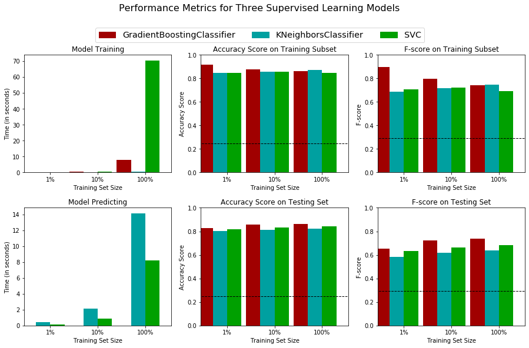

```python
# Import the three supervised learning models from sklearn
from sklearn.ensemble import GradientBoostingClassifier
from sklearn.neighbors import KNeighborsClassifier
from sklearn.svm import SVC

# Initialise the three models
clf_A = GradientBoostingClassifier(random_state = 10)
clf_B = KNeighborsClassifier(n_neighbors=5)
clf_C = SVC(random_state = 10, gamma='scale')

# Calculate the number of samples for 1%, 10%, and 100% of the training data
# To remember: samples_100 is the entire training set i.e. len(y_train)
# To remember: samples_10 is 10% of samples_100 (ensure to set the count of the values to be `int` and not `float`)
# To remember: samples_1 is 1% of samples_100 (ensure to set the count of the values to be `int` and not `float`)
samples_100 = len(y_train)
samples_10 = int(samples_100*0.1)
samples_1 = int(samples_100*0.01)

# Collect results on the learners
results = {}
for clf in [clf_A, clf_B, clf_C]:
    clf_name = clf.__class__.__name__
    results[clf_name] = {}
    for i, samples in enumerate([samples_1, samples_10, samples_100]):
        results[clf_name][i] = \
        train_predict(clf, samples, X_train, y_train, X_test, y_test)

# Run metrics visualisation for the three supervised learning models chosen
vs.evaluate(results, accuracy, fscore)
```

```python
# Display results in a table for legibility

for i in results.items():
    print(i[0])
    display(pd.DataFrame(i[1]).rename(columns={0:'1%', 1:'10%', 2:'100%'}))

# Source: https://www.geeksforgeeks.org/display-the-pandas-dataframe-in-table-style/
```

```
GradientBoostingClassifier
```

|  | 1% | 10% | 100% |
| --- | --- | --- | --- |
| train_time | 0.057252 | 0.529650 | 8.027240 |
| pred_time | 0.016587 | 0.015636 | 0.015625 |
| acc_train | 0.916667 | 0.876667 | 0.860000 |
| acc_test | 0.828856 | 0.855721 | 0.862797 |
| f_train | 0.895522 | 0.793651 | 0.738636 |
| f_test | 0.653412 | 0.721393 | 0.737687 |

```
KNeighborsClassifier
```

|  | 1% | 10% | 100% |
| --- | --- | --- | --- |
| train_time | 0.000000 | 0.015624 | 0.443799 |
| pred_time | 0.442055 | 2.157101 | 14.116293 |
| acc_train | 0.843333 | 0.856667 | 0.870000 |
| acc_test | 0.800221 | 0.814925 | 0.822001 |
| f_train | 0.683333 | 0.714286 | 0.743671 |
| f_test | 0.584020 | 0.619683 | 0.635705 |

```
SVC
```

|  | 1% | 10% | 100% |
| --- | --- | --- | --- |
| train_time | 0.000000 | 0.390656 | 70.402678 |
| pred_time | 0.124999 | 0.908085 | 8.224663 |
| acc_train | 0.843333 | 0.853333 | 0.843333 |
| acc_test | 0.820011 | 0.831177 | 0.840685 |
| f_train | 0.704545 | 0.722656 | 0.690299 |
| f_test | 0.634174 | 0.661722 | 0.681745 |

## Improving Results

In this final section, I choose from the three supervised learning models the *best* model to use on the student data. I will then perform a grid search optimisation for the model over the entire training set (`X_train` and `y_train`) by tuning at least one parameter to improve upon the untuned model's F-score.

### Question 3 - Choosing the Best Model

Based on the evaluation performed above, in one to two paragraphs, I will explain which of the three models I believe to be most appropriate for the task of identifying individuals that make more than \$50,000.

I will discuss my answer with reference to:

- metrics - F score on the testing when 100% of the training data is used,
- prediction/training time
- the algorithm's suitability for the data.

As the financial model of a charitable organisation is to spend the least possible on promotional activities, the best models would be the ones that take less time to train and predict; in this case Gradient Booster

### Question 4 - Describing the Model in Layman's Terms

- Here I will explain in simple terms how the final model chosen is supposed to work. I will describe the major qualities of the model, such as how the model is trained and how the model makes a prediction.

Gradient Boosting works on the concept of 'ensemble learning', that is to say: it uses 'weak learners' to build a stronger learner, using the mistakes of the weak learners to 'boost' itself. These weak learners are typically decisions trees (a flowchart of 'if' questions used to sort data).

This could be compared to the last student in a classroom to answer an exam question, after having heard the answers and critiques of those answers: the student would use the critiques he has heard to 'tune' his own answer and avoid making the same mistakes as others.

It uses a Loss Function to estimate how good our model has been at making predictions. In this case, we are trying to predict income level based on profiling features. The probability of earning up to 50,000 dollars can be 0 and earning above 50,000 dollars can be 1.

The model starts by taking an average of probabilities of each item in the training dataset and using this as it's first prediction, or 'line' on the graph, separating the points. It then measures how far each point is from the line (called a residual), converting the result to the probability of earning up to or above 50,000.

Each decision tree reaches it's end and compares it's prediction to the results of a training set of data (ringfenced for training of the model), the accuracy of this prediction is called the learning rate.

The Learning rate is then used to scale the contribution from the new tree. This results in a small step in the right direction of prediction. We repeat this process until we have a very small residual calculated, which indicates that the line fits the data well.

### Implementation: Model Tuning

In this step I will fine tune the chosen model. I use grid search (`GridSearchCV`) with at least one important parameter tuned with at least 3 different values. I use the entire training set for this.

A common problem with gradient boosted models is that they are quick to learn and overfit training data. A way to slow down learning in the gradient boosting model is to use a learning rate, therefore I will apply a lower and a higher learning rate than used previously, to see the effect.

In the code below, I implement the following:

- Import [`sklearn.grid_search.GridSearchCV`](http://scikit-learn.org/0.17/modules/generated/sklearn.grid_search.GridSearchCV.html) and [`sklearn.metrics.make_scorer`](http://scikit-learn.org/stable/modules/generated/sklearn.metrics.make_scorer.html).
- Initialize the classifier you've chosen and store it in `clf`.
  - Set a `random_state` if one is available to the same state you set before.
- Create a dictionary of parameters you wish to tune for the chosen model.
  - Example: `parameters = {'parameter' : [list of values]}`.
  - **Note:** Avoid tuning the `max_features` parameter of your learner if that parameter is available!
- Use `make_scorer` to create an `fbeta_score` scoring object (with $\beta = 0.5$).
- Perform grid search on the classifier `clf` using the `'scorer'`, and store it in `grid_obj`.
- Fit the grid search object to the training data (`X_train`, `y_train`), and store it in `grid_fit`.

```python
# Import 'GridSearchCV', 'make_scorer', and any other necessary libraries
from sklearn.metrics import make_scorer, fbeta_score,accuracy_score
from sklearn.model_selection import GridSearchCV
from sklearn.ensemble import GradientBoostingClassifier

# Initialise the classifier
clf = GradientBoostingClassifier(random_state = 10)

# Create the parameters list you wish to tune (at least 1 parameter, to 3 values), using a dictionary if needed
# parameters = {'parameter_1': [value1, value2], 'parameter_2': [value1, value2]}
# Avoid tuning the max_features if available
parameters = {'learning_rate' : [0.05, 0.1, 0.2]}

# Make an fbeta_score scoring object using make_scorer()
scorer = make_scorer(fbeta_score, beta = 0.5)

# Perform grid search on the classifier using 'scorer' as the scoring method using GridSearchCV()
grid_obj = GridSearchCV(clf, parameters, scorer)

# TODO: Fit the grid search object to the training data and find the optimal parameters using fit()
grid_fit = grid_obj.fit(X_train, y_train)

# Get the estimator
best_clf = grid_fit.best_estimator_

# Make predictions using the unoptimized and model
predictions = (clf.fit(X_train, y_train)).predict(X_test)
best_predictions = best_clf.predict(X_test)

# Report the before-and-afterscores
print("Unoptimised model\n------")
print("Accuracy score on testing data: {:.4f}".format(accuracy_score(y_test, predictions)))
print("F-score on testing data: {:.4f}".format(fbeta_score(y_test, predictions, beta = 0.5)))
print("\nOptimised Model\n------")
print("Final accuracy score on the testing data: {:.4f}".format(accuracy_score(y_test, best_predictions)))
print("Final F-score on the testing data: {:.4f}".format(fbeta_score(y_test, best_predictions, beta = 0.5)))
```

```
Unoptimised model
------
Accuracy score on testing data: 0.8628
F-score on testing data: 0.7377

Optimised Model
------
Final accuracy score on the testing data: 0.8670
Final F-score on the testing data: 0.7462
```

### Question 5 - Final Model Evaluation

- What is the optimised model's accuracy and F-score on the testing data?
- Are these scores better or worse than the unoptimised model?
- How do the results from your optimised model compare to the naive predictor benchmarks you found earlier in **Question 1**?

#### Results:

| Metric | Unoptimised Model | Optimised Model |
| --- | --- | --- |
| Accuracy Score | 0.8628 | 0.8670 |
| F-score | 0.7377 | 0.7462 |

The scores of the optimised model are slightly better than the unoptimised; showing that the tuning worked.

If I compare these to the results gotten from using Naive Predictor (Accuracy score: 0.2478, F-score: 0.2917), the results from the optimised model are vastly improved.

## Feature Importance

An important task when performing supervised learning on a dataset like the census data here is determining which features provide the most predictive power. By focusing on the relationship between only a few crucial features and the target label our understanding of the phenomenon is simplified, which is most always a useful thing to do. In the case of this project, that means I wish to identify a small number of features that most strongly predict whether an individual makes at most or more than \$50,000.

I choose a scikit-learn classifier (adaboost) that has a `feature_importance_` attribute, which is a function that ranks the importance of features according to the chosen classifier, fit this classifier to training set and use this attribute to determine the top 5 most important features for the census dataset.

### Question 6 - Feature Relevance Observation

When **Exploring the Data** in the first instance, there were thirteen available features for each individual on record in the census data. Of these thirteen records, which five features do you believe to be most important for prediction, and in what order would you rank them and why?

I believe the following 5 features may be the most important for prediction of income, without doing any manipulation of the data to arrive to this conclusion:

1. Capital gain - one could assume that someone with a high capital gain would also have a high income as they directly linked
2. Age - Similar with work class, one would assume a link between seniority and income level
3. Occupation - some occupations are typically better remunerated than other. Often linked to education level as well.
4. Education level - it is a common practice that studying to a higher level is rewarded with a higher salary.
5. Sex - there is a well-known gender pay gap phenomenon

### Implementation - Extracting Feature Importance

I have chosen a `scikit-learn` supervised learning algorithm that has a `feature_importance_` attribute availble for it. This attribute is a function that ranks the importance of each feature when making predictions based on the chosen algorithm.

In the code in cell below, I implement the following:

- Import a supervised learning model from sklearn if it is different from the three used earlier.
- Train the supervised model on the entire training set.
- Extract the feature importances using `'.feature_importances_'`.

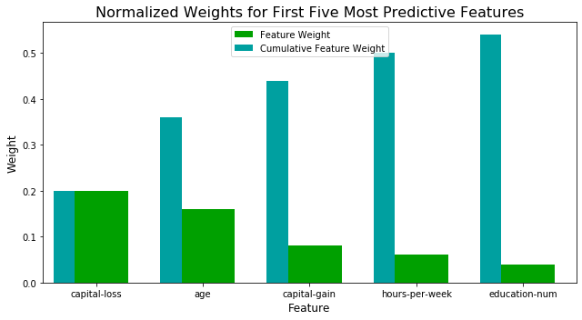

```python
# Import a supervised learning model that has 'feature_importances_'
from sklearn.ensemble import AdaBoostClassifier
clf2 = AdaBoostClassifier()

# Train the supervised model on the training set using .fit(X_train, y_train)
model = clf2.fit(X_train, y_train)

# Extract the feature importances using .feature_importances_
importances = model.feature_importances_

# Plot
vs.feature_plot(importances, X_train, y_train)
```

### Question 7 - Extracting Feature Importance

Observing the visualisation created above, I note the five most relevant features for predicting if an individual makes at most or above \$50,000:

- Capital loss
- Age
- Capital gain
- Hours per week
- Education-num

How do these five features compare to the five features discussed in **Question 6**?

If you were close, how does this visualisation confirm the previous thoughts?

If you were not close, why do you think these features are more relevant?

**Answer:**

In my previous prediction, I was correct in thinking that age and capital gain are amongst the top 5 most important predictors for income level.

However, I did not guess that capital loss, hours per week and education num would be amongst the top 5 features.

Capital loss makes sense because it refers to spending and logic would say that higher spending is normally a result of having a larger income.

Hours per week is a simple matter of more time worked equals more income. Whilst this is certainly true for jobs paid by the hour, in a salaried job, this doesn't make as much of a difference, nor if your income comes from passive sources such as renting a property.

I am pleased to see that sex was not among the top 5 most important predictors.

### Feature Selection

How does a model perform if we only use a subset of all the available features in the data? With less features required to train, the expectation is that training and prediction time is much lower — at the cost of performance metrics. From the visualisation above, it can be seen that the top five most important features contribute more than half of the importance of **all** features present in the data.

This suggests that I can attempt to *reduce the feature space* and simplify the information required for the model to learn.

The code in the cell below will use the same optimised model I found earlier, and train it on the same training set *with only the top five important features*.

```python
# Import functionality for cloning a model
from sklearn.base import clone

# Reduce the feature space
X_train_reduced = X_train[X_train.columns.values[(np.argsort(importances)[::-1])[:5]]]
X_test_reduced = X_test[X_test.columns.values[(np.argsort(importances)[::-1])[:5]]]

# Train on the "best" model found from grid search earlier
clf = (clone(best_clf)).fit(X_train_reduced, y_train)

# Make new predictions
reduced_predictions = clf.predict(X_test_reduced)

# Report scores from the final model using both versions of data
print("Final Model trained on full data\n------")
print("Accuracy on testing data: {:.4f}".format(accuracy_score(y_test, best_predictions)))
print("F-score on testing data: {:.4f}".format(fbeta_score(y_test, best_predictions, beta = 0.5)))
print("\nFinal Model trained on reduced data\n------")
print("Accuracy on testing data: {:.4f}".format(accuracy_score(y_test, reduced_predictions)))
print("F-score on testing data: {:.4f}".format(fbeta_score(y_test, reduced_predictions, beta = 0.5)))
```

```
Final Model trained on full data
------
Accuracy on testing data: 0.8670
F-score on testing data: 0.7462

Final Model trained on reduced data
------
Accuracy on testing data: 0.8411
F-score on testing data: 0.6963
```

### Question 8 - Effects of Feature Selection

- How does the final model's F-score and accuracy score on the reduced data using only five features compare to those same scores when all features are used?
- If training time was a factor, would you consider using the reduced data as your training set?

#### Results:

| Metric | Full Data | Reduced Data |
| --- | --- | --- |
| Accuracy Score | 0.8670 | 0.8411 |
| F-score | 0.7462 | 0.6963 |

**Answer:**

The model's accuracy and F-score drop slightly when we focus on only the top 5 features (accuracy reduced 0.0259, f-score reduced 0.0499).

However, the model using the top 5 still produces a very respectful accuracy and f-score, considering that we have removed over 60% of features.

Therefore, if time and computing power/expense was an important factor for the client (which is likely for a charity), I would consider using the reduced data as the training set, as the expense may well outweigh the cost of sending letters to any incorrectly classified individuals.